# p8105_hw3_my2644

ymysherry

10/9/2020

###problem 1

```r
data("instacart")
```

This dataset contains 1384617 rows and 15 columns.

Observations are the level of items in orders by user. There are user/order variables – user ID, order ID, order day, and order hour. There are also item variables – name, aisle, department, and some numeric codes.

1. How many aisles are there, and which aisles are the most items ordered from?

```r
instacart %>%
  count (aisle) %>%
  arrange (desc(n))
```

```
## # A tibble: 134 x 2
##    aisle                              n
##    <chr>                          <int>
##  1 fresh vegetables              150609
##  2 fresh fruits                  150473
##  3 packaged vegetables fruits     78493
##  4 yogurt                         55240
##  5 packaged cheese                41699
##  6 water seltzer sparkling water  36617
##  7 milk                           32644
##  8 chips pretzels                 31269
##  9 soy lactosefree                26240
## 10 bread                          23635
## # … with 124 more rows
```

2. Make a plot that shows the number of items ordered in each aisle, limiting this to aisles with more than 10000 items ordered. Arrange aisles sensibly, and organize your plot so others can read it.

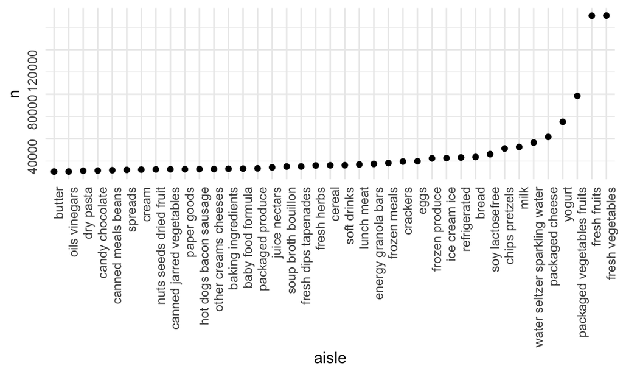

```r
instacart %>%
  count (aisle) %>%
  filter (n>10000) %>%
  mutate(
    aisle = factor(aisle),
    aisle = fct_reorder(aisle, n)
  ) %>%
  ggplot (aes(x = aisle, y = n)) + geom_point() + theme(axis.text = element_text(angle = 90, vjust = 0.5, hjust = 1))
```

3. Make a table showing the three most popular items in each of the aisles “baking ingredients”, “dog food care”, and “packaged vegetables fruits”. Include the number of times each item is ordered in your table.

```r
instacart %>%
  filter (aisle %in% c("baking ingredients", "dog food care", "packaged vegetables fruits")) %>%
    group_by(aisle) %>%
    count(product_name) %>%
    mutate(rank = min_rank(desc(n))) %>%
      filter(rank < 4) %>%
  arrange (aisle, rank) %>%
  knitr::kable()
```

| aisle | product_name | n | rank |
| --- | --- | --- | --- |
| baking ingredients | Light Brown Sugar | 499 | 1 |
| baking ingredients | Pure Baking Soda | 387 | 2 |
| baking ingredients | Cane Sugar | 336 | 3 |
| dog food care | Snack Sticks Chicken & Rice Recipe Dog Treats | 30 | 1 |
| dog food care | Organix Chicken & Brown Rice Recipe | 28 | 2 |
| dog food care | Small Dog Biscuits | 26 | 3 |
| packaged vegetables fruits | Organic Baby Spinach | 9784 | 1 |
| packaged vegetables fruits | Organic Raspberries | 5546 | 2 |
| packaged vegetables fruits | Organic Blueberries | 4966 | 3 |

4. Make a table showing the mean hour of the day at which Pink Lady Apples and Coffee Ice Cream are ordered on each day of the week; format this table for human readers (i.e. produce a 2 x 7 table).

```r
instacart %>%
  filter (product_name %in% c("Pink Lady Apples", "Coffee Ice Cream")) %>%
  group_by(product_name, order_dow) %>%
  summarize(mean_hour= mean(order_hour_of_day)) %>%
  pivot_wider(
    names_from = order_dow,
    values_from = mean_hour
  )
```

```
## # A tibble: 2 x 8
## # Groups:   product_name [2]
##   product_name       `0`   `1`   `2`   `3`   `4`   `5`   `6`
##   <chr>            <dbl> <dbl> <dbl> <dbl> <dbl> <dbl> <dbl>
## 1 Coffee Ice Cream  13.8  14.3  15.4  15.3  15.2  12.3  13.8
## 2 Pink Lady Apples  13.4  11.4  11.7  14.2  11.6  12.8  11.9
```

###Problem 2

1. Load, tidy, and otherwise wrangle the data. Your final dataset should include all originally observed variables and values; have useful variable names; include a weekday vs weekend variable; and encode data with reasonable variable classes. Describe the resulting dataset (e.g. what variables exist, how many observations, etc).

```r
accel_df = read_csv("./data/accel_data.csv") %>%
janitor::clean_names() %>%

pivot_longer(activity_1:activity_1440,
             names_to = "min_of_day",
             names_prefix = "activity_",
             values_to = "activity_count") %>%

  mutate(
         day=as.factor(day),
         activity_count=as.numeric(activity_count),
  min_of_day=as.numeric(min_of_day),
  day_id=as.numeric(day_id),
  week=as.numeric(week)
  ) %>%


  mutate(weekdays_vs_weekend = case_when(
           day  %in% c("Monday", "Tuesday", "Wednesday", "Thursday", "Friday") ~ "Weekdays",
          day  %in% c("Saturday", "Sunday") ~ "Weekend")) %>%

  select(week, weekdays_vs_weekend, day_id, day_of_wk=day,everything())
   cols(.default = col_double(),
        day=col_character())
```

The dataframe accel_df contains 50400 observations and 6 columns. Variables include week, day_id, day, min_of_day, activity_count, and weekdays_vs_weekend.

2. Traditional analyses of accelerometer data focus on the total activity over the day. Using your tidied dataset, aggregate accross minutes to create a total activity variable for each day, and create a table showing these totals. Are any trends apparent?

```r
accel_df %>%
  mutate(
         day_of_wk=as.factor(day_of_wk),
         activity_count=as.numeric(activity_count),
  min_of_day=as.numeric(min_of_day),
  day_id=as.numeric(day_id),
  week=as.numeric(week)
  ) %>%
   mutate(day_of_wk = forcats::fct_relevel(day_of_wk, c("Monday", "Tuesday", "Wednesday", "Thursday", "Friday", "Saturday", "Sunday"))) %>%

  group_by(week, day_of_wk, weekdays_vs_weekend) %>%
  summarise(total_daily_activity = sum(activity_count)) %>%

  knitr::kable()
```

| week | day_of_wk | weekdays_vs_weekend | total_daily_activity |
| --- | --- | --- | --- |
| 1 | Monday | Weekdays | 78828.07 |
| 1 | Tuesday | Weekdays | 307094.24 |
| 1 | Wednesday | Weekdays | 340115.01 |
| 1 | Thursday | Weekdays | 355923.64 |
| 1 | Friday | Weekdays | 480542.62 |
| 1 | Saturday | Weekend | 376254.00 |
| 1 | Sunday | Weekend | 631105.00 |
| 2 | Monday | Weekdays | 295431.00 |
| 2 | Tuesday | Weekdays | 423245.00 |
| 2 | Wednesday | Weekdays | 440962.00 |
| 2 | Thursday | Weekdays | 474048.00 |
| 2 | Friday | Weekdays | 568839.00 |
| 2 | Saturday | Weekend | 607175.00 |
| 2 | Sunday | Weekend | 422018.00 |
| 3 | Monday | Weekdays | 685910.00 |
| 3 | Tuesday | Weekdays | 381507.00 |
| 3 | Wednesday | Weekdays | 468869.00 |
| 3 | Thursday | Weekdays | 371230.00 |
| 3 | Friday | Weekdays | 467420.00 |
| 3 | Saturday | Weekend | 382928.00 |
| 3 | Sunday | Weekend | 467052.00 |
| 4 | Monday | Weekdays | 409450.00 |
| 4 | Tuesday | Weekdays | 319568.00 |
| 4 | Wednesday | Weekdays | 434460.00 |
| 4 | Thursday | Weekdays | 340291.00 |
| 4 | Friday | Weekdays | 154049.00 |
| 4 | Saturday | Weekend | 1440.00 |
| 4 | Sunday | Weekend | 260617.00 |
| 5 | Monday | Weekdays | 389080.00 |
| 5 | Tuesday | Weekdays | 367824.00 |
| 5 | Wednesday | Weekdays | 445366.00 |
| 5 | Thursday | Weekdays | 549658.00 |
| 5 | Friday | Weekdays | 620860.00 |
| 5 | Saturday | Weekend | 1440.00 |
| 5 | Sunday | Weekend | 138421.00 |

3. Accelerometer data allows the inspection activity over the course of the day. Make a single-panel plot that shows the 24-hour activity time courses for each day and use color to indicate day of the week. Describe in words any patterns or conclusions you can make based on this graph.

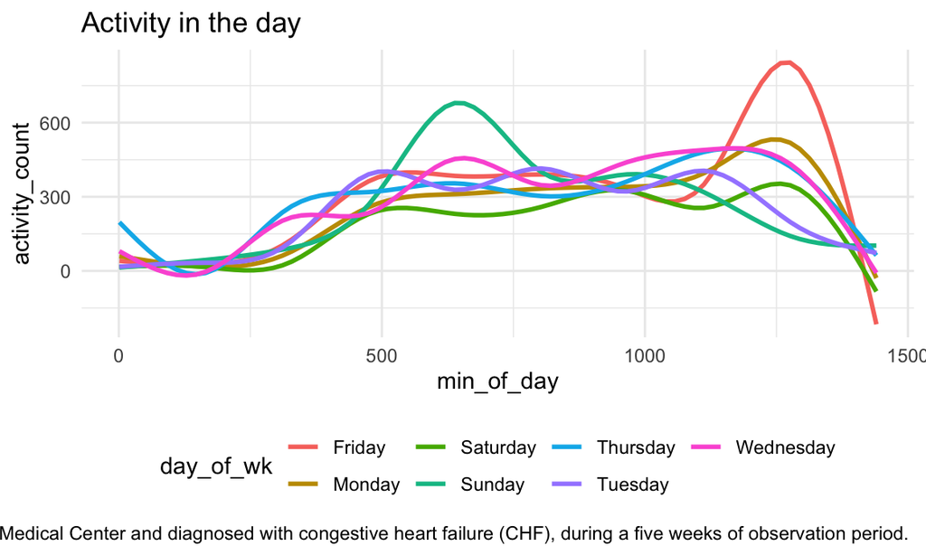

```r
accel_df %>%
  ggplot(aes(x = min_of_day, y = activity_count, color = day_of_wk)) +
  geom_smooth(se = FALSE) +
  theme(legend.position = "bottom") +
  labs(
    title = "Activity in the day ",
    caption = "Accelerometer Data collected on a 63 year-old male with BMI 25, who was admitted to the Advanced Cardiac Care Center of Columbia University Medical Center and diagnosed with congestive heart failure (CHF), during a five weeks of observation period. "
  )
```

From the plot we can notice that the male study object has more activities at noon and night during each day of the week, especially on the Friday and Sunday. During weekdays the activity counts are more stable throughout the day. Activity counts are lower during the Saturdays of each week.

###Problem 3 1. load dataset.Do some data cleaning. Create separate variables for year, month, and day. Ensure observations for temperature, precipitation, and snowfall are given in reasonable units. For snowfall, what are the most commonly observed values? Why?

```r
data("ny_noaa")
nycweather_df =
  ny_noaa %>%
  mutate(
    ny_noaa,
    prcp = prcp/10,
    tmax = as.numeric(tmax)/10,
    tmin = as.numeric(tmin)/10
  ) %>%
  janitor::clean_names() %>%
  drop_na() %>%
  separate(date, c("year", "month", "day")) %>%
  mutate(
    year = as.integer(year),
    month = month.name[as.integer(month)],
    day = as.integer(day)
    )

skimr::skim(nycweather_df)
```

Data summary

| Name | nycweather_df |
| --- | --- |
| Number of rows | 1222433 |
| Number of columns | 9 |
| _______________________ |  |
| Column type frequency: |  |
| character | 2 |
| numeric | 7 |
| ________________________ |  |
| Group variables | None |

**Variable type: character**

| skim_variable | n_missing | complete_rate | min | max | empty | n_unique | whitespace |
| --- | --- | --- | --- | --- | --- | --- | --- |
| id | 0 | 1 | 11 | 11 | 0 | 214 | 0 |
| month | 0 | 1 | 3 | 9 | 0 | 12 | 0 |

**Variable type: numeric**

| skim_variable | n_missing | complete_rate | mean | sd | p0 | p25 | p50 | p75 | p100 | hist |
| --- | --- | --- | --- | --- | --- | --- | --- | --- | --- | --- |
| year | 0 | 1 | 1994.84 | 8.56 | 1981.0 | 1988.0 | 1994.0 | 2002.0 | 2010.0 | ▇▇▇▆▆ |
| day | 0 | 1 | 15.71 | 8.80 | 1.0 | 8.0 | 16.0 | 23.0 | 31.0 | ▇▇▇▇▆ |
| prcp | 0 | 1 | 3.01 | 7.92 | 0.0 | 0.0 | 0.0 | 2.3 | 2032.5 | ▇▁▁▁▁ |
| snow | 0 | 1 | 4.65 | 25.58 | -13.0 | 0.0 | 0.0 | 0.0 | 7765.0 | ▇▁▁▁▁ |
| snwd | 0 | 1 | 36.66 | 112.72 | 0.0 | 0.0 | 0.0 | 0.0 | 9195.0 | ▇▁▁▁▁ |
| tmax | 0 | 1 | 14.65 | 11.00 | -38.9 | 5.6 | 16.1 | 23.9 | 44.4 | ▁▁▅▇▂ |
| tmin | 0 | 1 | 3.63 | 10.25 | -58.3 | -2.8 | 4.4 | 11.7 | 37.2 | ▁▁▅▇▁ |

This dataset collects the data of weather conditions from all monitoning stations in NY, during January 1, 1981 through December 31, 2010. It contains 1222433 rows and 9 columns. There are 9 Variables, which include year, month, day, prcp (precipitation (mm)), snow (snowfall (mm)), snwd (snow depth (mm)), tmax (maximum temperature (degrees Celcius)), and tmin (minimum temperature (degrees Celcius)). The original dataset contains 2595176 observations, and 1372743 , Observations with missing data were removed from the original dataset.

```r
nycweather_df %>%
  count(snow) %>%
  arrange(desc(n))
```

```
## # A tibble: 248 x 2
##     snow       n
##    <int>   <int>
##  1     0 1112758
##  2    25   15809
##  3    13   12460
##  4    51    9252
##  5     5    5669
##  6     8    5380
##  7    76    5296
##  8     3    5276
##  9    38    5050
## 10   102    3386
## # … with 238 more rows
```

For snowfall, 0mm,25mm and 13mm are the three most commonly observed values, since snowfall is only occurring in winter during the year.

2. Make a two-panel plot showing the average max temperature in January and in July in each station across years. Is there any observable / interpretable structure? Any outliers?

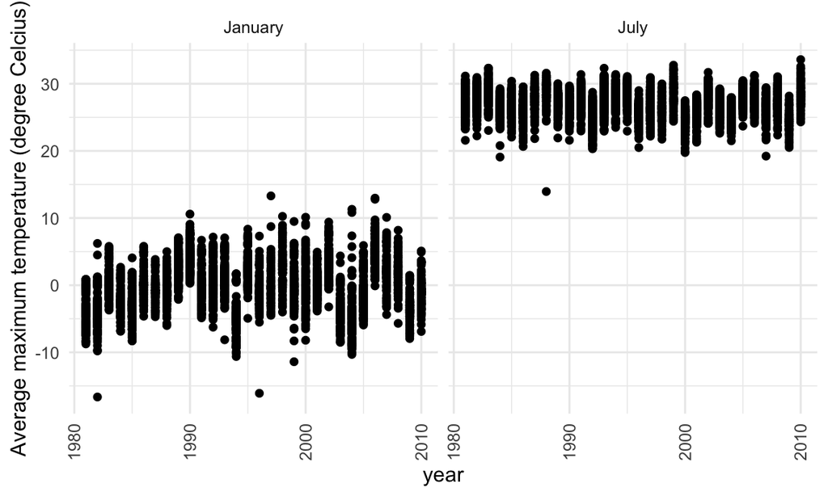

```r
nycweather_df %>%
  filter(month %in% c("January", "July")) %>%
  group_by(month, id, year) %>%
  summarise(n = mean(tmax)) %>%

  ggplot(aes(x = year, y = n, group = id)) +
  geom_point() +
  facet_grid(. ~ month) +
  geom_smooth(se = FALSE) +
  theme(legend.position = "bottom", axis.text.x = element_text(angle = 90, vjust = 0.5, hjust = 1)) +
  labs(y = "Average maximum temperature (degree Celcius)")
```

The average maximum temperature in July is significantly higher than that in January across years. The distribution of max temperature is larger in January than in July, with more outliers of extremely low tempetaure arouud -10 to -15 degrees. In comparison, July has 1 outlier in the lower range around 15 degrees.

3. Make a two-panel plot showing (i) tmax vs tmin for the full dataset (note that a scatterplot may not be the best option); and (ii) make a plot showing the distribution of snowfall values greater than 0 and less than 100 separately by year.

```r
t_maxmin_p =
  nycweather_df %>%
  ggplot(aes(x = tmin, y = tmax)) +
  geom_bin2d() +
  labs(
    title = "tmax vs tmin",
    caption = "Data retrieved from the ny_noaa dataset from all  monitoning stations in NY, during January 1, 1981 through December 31, 2010."
  )
ggsave("t_maxmin_plot.pdf", t_maxmin_p, width = 8, height = 5)

snowfall_p =
  nycweather_df %>%
  filter(snow > 0 & snow < 100) %>%
  ggplot(aes(x = year, y = snow)) +
  geom_boxplot() +
  theme(axis.text.x = element_text(angle = 90, vjust = 0.5, hjust = 1)) +
  labs(
  title = "Snowfall Distribution",
  caption = "Data from the ny_noaa dataset from all  monitoning stations in NY, during January 1, 1981 through December 31, 2010."
  )
ggsave("snowfall.pdf", snowfall_p, width = 8, height = 5)
knitr::opts_chunk$set(
  fig.width = 6,
  fig.asp = .6,
  out.width = "90%"
)
```

[output not shown]